# control flow in R_loop

chenzhiming

2024-10-9

# 1 背景介绍

继续准备并记录基于R语言的高效质量管理相关内容。本文速记一个关于SPC 控制图判异准则实现相关的基础算法。

有了这些基础函数或算法逻辑基础储备，后续做函数及绘制数据图表就比较轻松了。

质量管理中的控制图中，有基于一定规则的异常点判定的方法论和思路。

先不管实践中这种判异能带来多少价值，但作为一种方法论，他一直存在。存在即合理。

Minitab软件里预制了8类选项，通常我们会选择其中部分或全部判断项，并根据实际情况对其中参数进行修订。

规则有一项为连续6个(及以上)点全部递增或全部递减，如何在R中实现这一规则的识别并在控制图中实现呢？

# 2 R语言实现

实现的方法挺多的。本文通过几个简单例子，进行速记。

样本数据如下：

```r
testvalue <- c(1,45,3,7,5,78,120,123,124,125,126,127,32,34,45,67,98,120,167,234,12,34,2,4,1)
```

## 2.1 基础方法

比较直观，但可能不优雅的做法就是增加辅助列的思维。

对于长度为n的向量v[1:n],

1. 使用diff()函数计算v[i+1]-v[i] (i in 2:n);
2. 计算结果与0比较，正值取值1，负值取-1，使用sign()函数实现；
3. 计算1和-1 连续出现的次数,使用rle()函数，得到两组数据，1和-1值以及对应的长度值。

显然，对于本文所列规则:连续6个及以上点全部递增或递减；当长度值大于等于6时，即需做判异处理。

通过长度值向量结果，能过比较便捷的找到对应异常点的位置。

我们用样例数据来实现。

```r
# 加载包
library(tidyverse)

# 1.求差值
rle_result <- diff(testvalue) %>%

# 2.对差值结果编码,递增1，递减-1
     sign() %>%

# 3.计算连续递增/递减次数
     rle()
```

我们对lengths数据进行累积求和，即能求得两次连续递增的起止点位置。

```r
rle_result$lengths %>%
    cumsum()
```

```
##  [1]  1  2  3  4 11 12 19 20 21 22 23 24
```

第一次连续上升始于第4位，结束于第11位；

第二次连续上升始于第12位，结束于第19位；

因为该数据相对原数据进行过一次diff()函数计算，原数据起始位置需增加1位。

这个方法胜在基本不需要自己编写任何脚本，直接做调包侠调用函数即可实现基础功能，而且能够比较快速获取数据集中的异常数据集以及数据点。当数据集长度较大时，能省去很多人为统计识别的工作量。

## 2.2 调用函数+自定义循环计算

我们可以在上述方法思路的基础上，进行一些优化，以更直观的显示各个数据点的递增递减状态，并直接用于绘图。

以testvalue为例，我们对其diff()函数求值后，在进行sign()处理，得到一组数据集S。

根据S数据集的结果来确定testvalue数据集中各位置数据点连续上升/下降的次数，比如本例中，当次数大于等于6时，做特殊标记。

下述代码实现上述功能，并函数化。

```r
get_violations_6 <- function(x){
   # 非正式生产用函数。这里只做简单速记，不对输入x进行判断是否为向量，还是数据框，也不进行是否为数据型向量进行判断，默认数据符合要求。
    S <- x %>%
         diff(.,lag = 1) %>%
         sign()
    S <- c(0,S) #数据集第一位不参与连续递增递减比较，diff后的sign值补齐1位。
    result = c()
    result[1] = 0

for (i in 2:length(S)){
  if (S[i] == S[i-1]){
    result[i] =  result[i-1] + 1
  }else{
    result[i] = 1
  }
}
violations_p = ifelse(result>=6,1,0)
 df <- data.frame(value = x,
                   sign = S,
                   result = result,
                  violations_p = violations_p)

    return(df)
}
```

现在，我们可以用上述函数进行数据图绘制了.

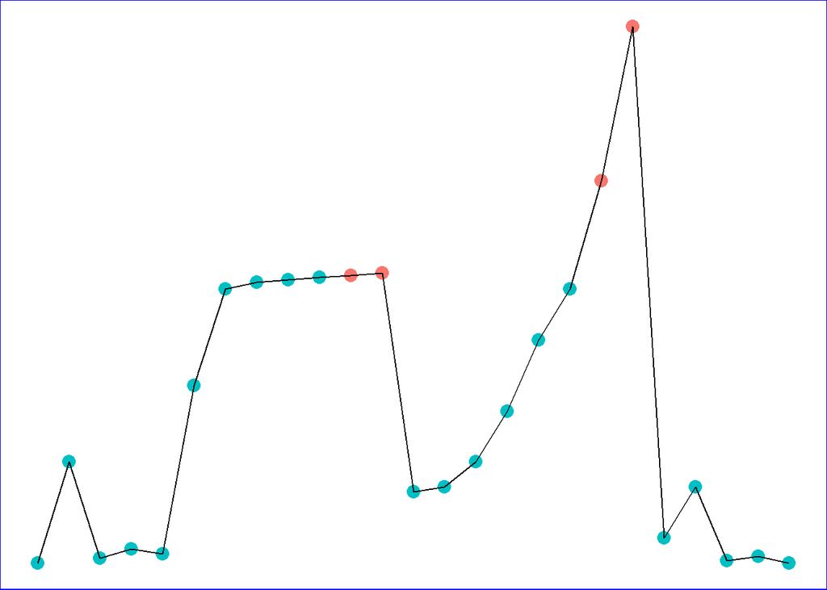

```r
plot_data <- get_violations_6(testvalue)

    ggplot(plot_data,aes(x = 1:nrow(plot_data),
                         y = value))+
    geom_point(aes(color = as.factor(- violations_p)),size = 3.5)+
        geom_line(aes(group = 1),linewidth = 0.4) +
        theme_void()+
        theme(legend.position = "none",plot.background = element_rect(color = "blue"))
```

如图，第6，7个连续递增点被不同颜色标识出来了。

这看上去也不是很复杂。

## 2.3 R语言实现最长连续递增序列算法

循着上述函数的思路和逻辑，我们其实可以实现最长连续递增序列，最长递增子序列等常见的算法题。只需要将上述函数中使用到的diff()函数和sign()用自己的语言编写一遍。

但显然，从算法的角度来看，这不是最好的选择。

本文延展开，记录用R语言手撸获取最长连续递增序列数，并返回序列值，同时，考虑在提供的数组中存在并列最大连续递增序列的情形，输出全量，也就是多组结果的情形。

- 思路方法简单说明

本质是比较简单的，找到一组数据V(1:n)中若干个满足连续递增(Vi,Vi+1,Vi+2…Vi+m) 也就是V[i+1]>v[i],那么这个m的最大值就 最长连续递增次数，或者说长度。

我们假设第一个值的连续递增长度为1(也可以为0，就看怎么理解)，我们比较V[i] 与V[i-1]，如果结果是后者大于前者，对应位置的递增长度为上一位置数值数值递增长度+1，否则回到起点(0/1),依次循环，即可获得最大值及其所在的位置。

下面撸一个函数来实现。

```r
LCIS <- function(input_data) {
    result <- 1
    t <- 1
    n <- length(input_data)
    list_p <- c()
    list_p[1] <- 1
    for (i in 2:n){
        if (input_data[i]>input_data[i-1]){
            t <- t+1
            list_p[i] <- max(t,result)
        } else
        {t<- 1
        list_p[i] <- t}
    }
    m <- max(list_p)
     end_position <- which(list_p == m)

     output <- vector(mode = "list",length = length(end_position))

     # start_position <- end_position-max(list_p) +1
  for (k in 1:length(end_position)){
      output[[k]] <-input_data[(end_position[[k]]-m+1):end_position[[k]]]


  }

    #  output <- vector(mode = "list",
    #                   length = length(end_position))
    #
    #  for(k in 1:length(end_position)){
    # output[k] <- data[c((end_position[k]-max(list_p)+1):end_position[k])]
    #
    #      }
     return(list(output, paste0("length of longest continual increased series is ",m)))
}
LCIS(testvalue)
```

```
## [[1]]
## [[1]][[1]]
## [1]   5  78 120 123 124 125 126 127
##
## [[1]][[2]]
## [1]  32  34  45  67  98 120 167 234
##
##
## [[2]]
## [1] "length of longest continual increased series is 8"
```

8个数字在最长连续递增序列中，这个序列有8个数值。但第一个值对比排在他前面的值是更小的，或者他前面没有数值。

结果符合我们的预期。

本文可算作之前发的一篇R语言控制流之循环文章的应用，也是R语言算法的基础内容实践，当然也是质量管理相关内容的基础。

本文同时涉及到在R语言中对不同数据取子集的内容，下一篇文章会系统总结梳理一下，在R中取子集的常规做法，以及妙用取子集实现一些简单算法。